# 5-Fold Cross Validation

Daivd Leslie

Monday, March 16, 2015

The purpose of the code is to evaluate how well the 5-fold method protects a model against overfitting. In order to acomplish this, the predictive power of each model, or in other words, how well each test set (fold) predicts the train set will be judged. Let’s first start by generating a popluation, which we will sample from.

```r
# Create predictor variables
set.seed(10)
pop = 9000
x1 = rnorm(pop)
x2 = rnorm(pop)
x3 = rnorm(pop)

# Create noise
noise = rnorm(pop,0,3)

# Generate responce: additive model plus noise, intercept = 0
y = 2*x1 + x2 + 3*x3 + noise

# Organize predictors and responce in data frame
pop_data = data.frame(y, x1, x2, x3)

head(pop_data)
```

```
##            y          x1          x2         x3
## 1 -0.9350841  0.01874617 -0.97718623 -0.9620658
## 2 -5.0348547 -0.18425254 -1.15456052 -0.7386388
## 3 -3.3519495 -1.37133055 -0.05577223  0.4370131
## 4 -6.7564424 -0.59916772  0.61778059 -0.1895484
## 5  1.8298094  0.29454513  1.38595893  0.2462712
## 6  1.6258103  0.38979430  1.72930724 -0.1739482
```

Now that we have our population, lets take a sample from it and construct a model using that sample data.

```r
# Create sample population
n = 375
samp = pop_data[sample(nrow(pop_data), n), ]
# Create model(s)
mod = lm(y ~ x1 + x2 + x3, data=samp)

head(samp)
```

```
##                y         x1          x2         x3
## 2854 -0.85620190 -1.5001283 -0.62887799  1.5963321
## 2649  6.39325405  0.7223446 -1.48737954  0.6946828
## 4048  0.44202209  0.1743296 -1.61610788  0.1513150
## 7097  0.03740653  1.2473084  0.38821286 -0.2716728
## 777   4.42426709  1.3181781  0.01452238  0.7874660
## 8754 -3.96262376 -1.4606531  0.79233711 -0.1249875
```

```r
summary(mod)
```

```
##
## Call:
## lm(formula = y ~ x1 + x2 + x3, data = samp)
##
## Residuals:
##     Min      1Q  Median      3Q     Max
## -7.8807 -1.9683  0.0068  2.0143  8.3742
##
## Coefficients:
##             Estimate Std. Error t value Pr(>|t|)
## (Intercept)  -0.2321     0.1596  -1.454    0.147
## x1            1.9598     0.1501  13.057  < 2e-16 ***
## x2            1.2881     0.1576   8.172 4.83e-15 ***
## x3            2.9242     0.1590  18.394  < 2e-16 ***
## ---
## Signif. codes:  0 '***' 0.001 '**' 0.01 '*' 0.05 '.' 0.1 ' ' 1
##
## Residual standard error: 3.083 on 371 degrees of freedom
## Multiple R-squared:  0.6039, Adjusted R-squared:  0.6007
## F-statistic: 188.5 on 3 and 371 DF,  p-value: < 2.2e-16
```

Looking at the model summary, it appears that calculated coeffeicents are fairly close to actaul coefficents. It also appears that approximately 60% of the variability can be explained by the predictor variables. While this r squared value is good, we still have no idea how good the model will be a predicting on new data. In order to accploish this, lets split the data into five test and training sets to see if:

1. How much the r squared value changes.
2. How much the coeffcients vary

```r
library(lattice)
library(DAAG)
cv.lm(df=samp, mod, m=5)
```

```
## Analysis of Variance Table
##
## Response: y
##            Df Sum Sq Mean Sq F value  Pr(>F)
## x1          1   1491    1491   156.9 < 2e-16 ***
## x2          1    669     669    70.3 1.1e-15 ***
## x3          1   3216    3216   338.3 < 2e-16 ***
## Residuals 371   3526      10
## ---
## Signif. codes:  0 '***' 0.001 '**' 0.01 '*' 0.05 '.' 0.1 ' ' 1
```

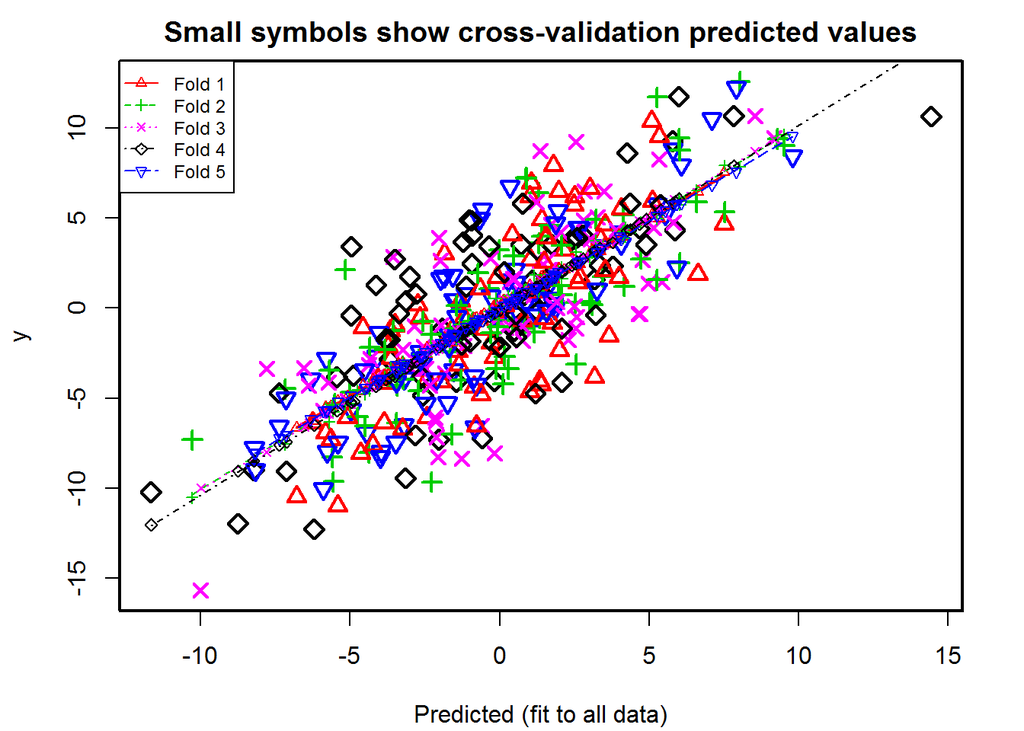

```
##
## fold 1
## Observations in test set: 75
##              8754  1756  3584     466   4092   2127 1861 1023   867  1213
## Predicted   -2.44  5.08 -1.41 -6.2495 -3.510  0.787 1.40 1.97 0.421 5.113
## cvpred      -2.56  5.15 -1.24 -6.2822 -3.386  0.796 1.15 2.20 0.530 4.965
## y           -3.96 10.35 -2.38 -6.3781 -0.977 -0.722 4.94 6.49 4.086 5.938
## CV residual -1.40  5.20 -1.14 -0.0959  2.409 -1.518 3.79 4.30 3.556 0.973
##             7513   4370   8229  2383   5582  2464  6619    439   2056
## Predicted   4.07 -1.596 -0.283 -3.65 -2.734  2.61  1.37 -3.621 -1.199
## cvpred      3.97 -1.918 -0.397 -3.46 -2.789  2.51  1.27 -3.441 -1.253
## y           5.50 -1.219 -1.919 -1.23  0.205  1.40 -4.24 -2.755 -0.523
## CV residual 1.53  0.699 -1.522  2.23  2.993 -1.11 -5.51  0.686  0.730
##              5321   3028 6905  2821  2947  5579   5981   2978   2210 2702
## Predicted   -4.66  1.391 2.49  6.62 -5.83 -1.95 -3.836  0.998 -0.521 1.50
## cvpred      -4.64  1.714 2.40  6.47 -5.50 -1.99 -3.758  1.249 -0.323 1.59
## y           -8.05  0.912 5.74  1.88 -6.91 -4.09 -4.186 -4.631 -1.165 3.91
## CV residual -3.41 -0.802 3.34 -4.59 -1.40 -2.11 -0.428 -5.881 -0.842 2.32
##             3353 5545  8670    6442   7746   2665 3314 5816  1508  8645
## Predicted   2.16 1.05 -1.36 -0.1816 -4.079 -1.319 2.51 3.52  3.16  1.34
## cvpred      2.13 1.10 -1.16 -0.0798 -4.084 -1.111 2.61 3.54  3.18  1.31
## y           3.24 6.96 -3.16 -2.7263 -3.940  0.407 6.21 4.64 -3.82 -4.02
## CV residual 1.11 5.86 -2.00 -2.6465  0.145  1.518 3.60 1.11 -7.00 -5.33
##              4872   4915  1515   325  3122    4210  1428   2425  2850
## Predicted    1.75 -3.502 -2.43 1.016 -5.64 -0.0883 -1.85  -6.80 3.375
## cvpred       1.69 -3.535 -2.22 0.761 -5.44  0.0659 -1.77  -6.65 3.139
## y           -0.84 -0.908 -6.09 2.663 -7.30  1.7285  3.02 -10.47 3.824
## CV residual -2.53  2.627 -3.87 1.902 -1.87  1.6625  4.78  -3.82 0.685
##              4219   3111  5568   6307   708   7008  8542 5023   2105  270
## Predicted   0.999  1.473  7.50 -0.854 -3.24  2.684 -4.57 1.80 -2.659 3.02
## cvpred      0.970  1.756  7.53 -0.599 -2.98  2.452 -4.27 1.57 -2.590 3.08
## y           6.194 -0.592  4.65 -4.388 -6.71  1.721 -1.10 7.92 -0.547 6.66
## CV residual 5.225 -2.347 -2.88 -3.789 -3.73 -0.731  3.17 6.35  2.043 3.58
##              8562  1931   1374 1881  4099  1102 5578 7213     142  6748
## Predicted   -3.73  3.99  -5.42 1.48  3.51  3.65 1.55 5.34 -0.1918  2.01
## cvpred      -3.68  4.08  -5.14 1.27  3.64  3.55 1.42 4.98 -0.2644  2.12
## y           -2.13  1.72 -10.95 2.56  2.11 -1.53 3.89 9.51 -0.1850 -2.36
## CV residual  1.55 -2.36  -5.82 1.29 -1.53 -5.08 2.47 4.54  0.0794 -4.48
##              6016    5802  2100   2865   4580  8897   6049
## Predicted   -3.87  0.1469 -4.25 -0.776 -0.656 -5.10 -0.627
```

[output cut: 174 more lines]

```
## Predicted   -3.47 -3.97 2.69 -5.41 5.80  7.90  1.559 -4.05 -0.780 -3.452
## cvpred      -3.45 -3.91 2.59 -5.19 5.71  7.56  1.435 -4.01 -0.858 -3.508
## y           -7.45 -7.96 4.45 -7.47 8.80 12.22 -0.172 -1.37 -4.266 -4.095
## CV residual -4.00 -4.05 1.86 -2.27 3.09  4.65 -1.607  2.63 -3.408 -0.587
##               8990 1517  7836   2903    377   3069 6990  1672  1387  4704
## Predicted    -5.90 6.07 -2.47 -0.830 -0.860 -1.444 1.87  5.93 -7.15 -3.98
## cvpred       -5.70 5.81 -2.44 -0.747 -0.974 -1.506 1.75  5.77 -7.04 -3.95
## y           -10.05 7.94 -5.31 -6.640 -3.808 -0.499 4.70  2.26 -5.01 -8.28
## CV residual  -4.36 2.13 -2.87 -5.893 -2.834  1.007 2.95 -3.50  2.03 -4.34
##
## Sum of squares = 487    Mean square = 6.49    n = 75
##
## Overall (Sum over all 75 folds)
##   ms
## 9.67
```